# Getting started with Coinmarketcapr

AbdulMajedRaja

This vignette is to help you get started with Coinmarketcapr Package that helps to extract and monitor price and market cap of Cryptocurrencies from **CoinMarketCap**. Simply, Coinmarketcapr is an R-binding for Coinmarketcap API that lists Price, Marketcap, Transaction Volume of many Cryptocurrencies and tokens.

### Basic Functions without API-key

This package contains four primary functions:

- `get_valid_currencies()`
- `get_global_marketcap()`
- `get_marketcap_ticker_all()`
- `plot_top_currencies()`

### Getting Valid Currrenices

This function `get_valid_currencies()` lists a character vector with all the valid currencies (ISO Codes) supported by Coinmarketcap API. These currency codes can be used in other functions like `get_global_marketcap()` to extract values in the given currency.

```r
library(coinmarketcapr)
get_valid_currencies()
```

```
#>  [1] "AUD" "BRL" "CAD" "CHF" "CLP" "CNY" "CZK" "DKK" "EUR" "GBP" "HKD" "HUF"
#> [13] "IDR" "ILS" "INR" "JPY" "KRW" "MXN" "MYR" "NOK" "NZD" "PHP" "PKR" "PLN"
#> [25] "RUB" "SEK" "SGD" "THB" "TRY" "TWD" "ZAR" "USD"
```

### Getting Global Marketcap

The function `get_global_marketcap()` fetches the USD value of global marketcap of all cryptocurrencies.

```r
library(coinmarketcapr)
coinmarketcapr::setup()
get_global_marketcap()
```

```
#> ⚠ The old API is used when no 'apikey' is given.
#>   total_market_cap_usd total_24h_volume_usd bitcoin_percentage_of_market_cap
#> 1          2.02011e+11          53868397517                            65.45
#>   active_currencies active_assets active_markets        last_updated
#> 1               841          1507          20660 2019-12-03 18:37:35
```

### Extracting all Cryptocurrencies

The function `get_crypto_listings()` gets various useful values such as Price, Marketcap, Total Volume, 24-hour Change and much more for all the cryptocurrencies.

```r
library(coinmarketcapr)
names(get_crypto_listings())
```

```
#> ⚠ The old API is used when no 'apikey' is given.
#>  [1] "id"                 "name"               "symbol"
#>  [4] "rank"               "price_usd"          "price_btc"
#>  [7] "X24h_volume_usd"    "market_cap_usd"     "available_supply"
#> [10] "total_supply"       "max_supply"         "percent_change_1h"
#> [13] "percent_change_24h" "percent_change_7d"  "last_updated"
```

### Plotting Top Cryptocurrencies

The function `plot_top_currencies()` makes it straightforward to make a barplot of top cryptocurrencies by their rank, based on Market cap.

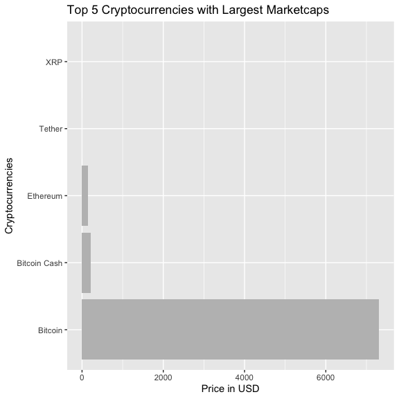

Plotting Top 5 Cryptocurrencies

```r
library(coinmarketcapr)
plot_top_currencies('USD',5)
```

### Plotting with Themes

`plot_top_currencies()` outputs a `ggplot` object hence using `+` operator a new ggplot2 theme can be applied. `ggthemes` package offers a rich set of out-of-the-box themes.

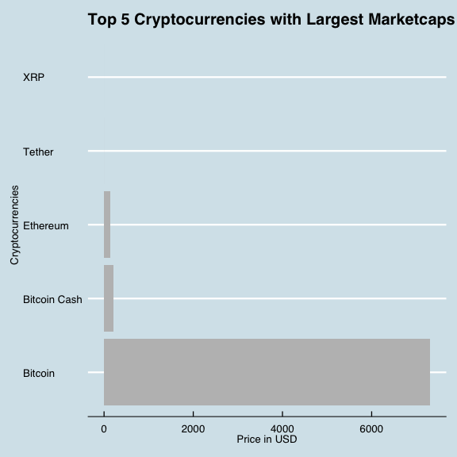

Plot with Themes

```r
library(ggthemes)
plot_top_currencies() +
        theme_economist()
```

### Cryptocurrencies Market - Tidy Analysis

Since `coinmarketcapr`’s `get_crypto_listings()` returns a dataframe, it could be fit in alongside with Tidy Data pipeline.

```r
library(coinmarketcapr)
library(dplyr)
```

```
#> ⚠ The old API is used when no 'apikey' is given.
```

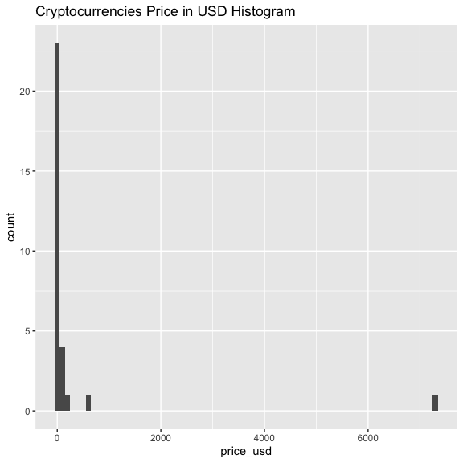

Cryptocurrencies Price in USD Histogram

```r
library(ggplot2)

get_crypto_listings() %>%
        slice(1:30) %>%
        mutate(price_usd = as.numeric(price_usd)) %>%
        ggplot() + geom_histogram(aes(price_usd), binwidth = 100) +
        ggtitle('Cryptocurrencies Price in USD Histogram')
```

### Courtesy

Coinmarketcapr is powered by Coinmarketcap.com https://coinmarketcap.com/api/